# Module 9

STAT 6021

Taylor R. Brown, PhD

# Logistic Regression: Motivation

So far we’ve assumed $y$ is normal. In particular it is continuous and takes values on $\mathbb{R}$.

What if $y_i \in \{0,1\}$? Can we still use

$$y_i = \mathbf{x}_i^\intercal \boldsymbol{\beta} + \epsilon_i?$$

# Logistic Regression: Motivation

So far we’ve assumed $y$ is normal. In particular it is continuous and takes values on $\mathbb{R}$.

What if $y_i \in \{0,1\}$? Can we still use

$$y_i = \mathbf{x}_i^\intercal \boldsymbol{\beta} + \epsilon_i?$$

Problems:

- $y_i$ is a Bernoulli rv
- its average $p_i \in [0,1]$,
- but $\beta_0 + \beta_1 x \in \mathbb{R}$
- its variance $p_i(1-p_i)$ isn’t constant
- the errors can’t be normal

# Two Special Functions

Two special functions: the **logit function,** and the **inverse logit** (aka **logistic sigmoid** function).

The logit function expands a probability to lie on the real line.

$$\text{logit} : [0,1] \to \mathbb{R}$$

The inverse logit function “squashes” a real number into a probability (“sigmoid” means s-shaped).

$$\text{invlogit} : \mathbb{R} \to [0,1]$$

# Two Special Functions

1. $\text{logit}(p) : [0,1] \to \mathbb{R}$
   $$\text{logit}(p) = \log\left( \frac{p}{1-p}\right)$$

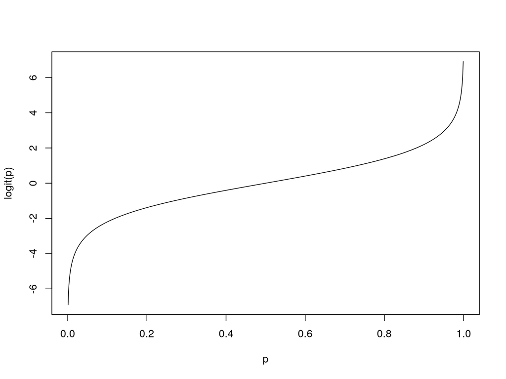

```r
library(boot) # for logit()
ps <- seq(0, 1, .001)
plot(ps, logit(ps), type ="l", xlab = "p", ylab = "logit(p)")
```

# Two Special Functions

1. $\text{invlogit}(p) : \mathbb{R} \to [0,1]$
   $$\text{invlogit}(x) = \frac{e^x}{1+e^x} = \frac{1}{1 + e^{-x}}$$

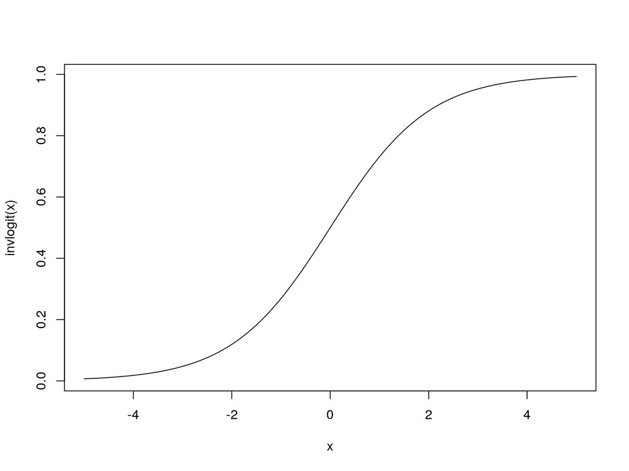

```r
library(boot) # for inv.logit()
xs <- seq(-5, 5, .001)
plot(xs, inv.logit(xs), type ="l", xlab = "x", ylab = "invlogit(x)")
```

# Two Special Functions

As the names suggest, they are inverses of each other:

$$\text{invlogit}[\text{logit}(p)] = \frac{ 1 }{1 +(1-p)/p} = p$$

Also, note that
$$1 - \text{invlogit}(x) = \text{invlogit}(-x)$$

# Model Specification

So there are two ways to write our model. Each $y_i \sim \text{Bernoulli}(\pi_i )$ where $\pi_i = P(y_i = 1 \mid \mathbf{x}_i, \boldsymbol{\beta})$ and where

$$\text{logit}(\pi_i) = \mathbf{x}_i^\intercal \boldsymbol{\beta}$$

or equivalently

$$\pi_i = \text{invlogit}(\mathbf{x}_i^\intercal \boldsymbol{\beta} )$$

# Maximum Likelihood Estimation (MLE)

First, let’s write down the likelihood:

$$L(\mathbf{y} ; \mathbf{X}, \boldsymbol{\beta}) = \prod_{i=1}^n f(y_i ; \mathbf{x}_i, \boldsymbol{\beta}) = \prod_{i=1}^n \pi_i^{y_i}(1-\pi_i)^{1-y_i} = \prod_{i=1}^n\left( \frac{\pi_i}{1-\pi_i}\right)^{y_i} (1 - \pi_i)$$

# Maximum Likelihood Estimation (MLE)

Now the log-likelihood from $L(\mathbf{y} ; \mathbf{X}, \boldsymbol{\beta}) = \prod_{i=1}^n\left( \frac{\pi_i}{1-\pi_i}\right)^{y_i} (1 - \pi_i)$

$$\begin{align*}
\log L(\mathbf{y} ; \mathbf{X}, \boldsymbol{\beta}) &= \sum_{i=1}^n y_i \log \left( \frac{\pi_i}{1-\pi_i}\right) + \log(1-\pi_i) \\
&= \sum_{i=1}^n y_i \text{logit} \left( \pi_i \right) + \log(1-\pi_i) \\
&= \sum_{i=1}^n y_i \mathbf{x}_i^\intercal \boldsymbol{\beta} + \log( 1 - \text{invlogit}(\mathbf{x}_i^\intercal \boldsymbol{\beta} )) \\
&= \sum_{i=1}^n y_i \mathbf{x}_i^\intercal \boldsymbol{\beta} + \log( \text{invlogit}( - \mathbf{x}_i^\intercal \boldsymbol{\beta} )) \\
&= \sum_{i=1}^n y_i \mathbf{x}_i^\intercal \boldsymbol{\beta} - \log( 1 + \exp[ \mathbf{x}_i^\intercal \boldsymbol{\beta}] ))
\end{align*}$$

# Maximum Likelihood Estimation (MLE)

Now take the derivatives of $\ell(\boldsymbol{\beta}) = \log L(\mathbf{y} ; \mathbf{X}, \boldsymbol{\beta}) = \sum_{i=1}^n y_i \mathbf{x}_i^\intercal \boldsymbol{\beta} - \log( 1 + \exp[ \mathbf{x}_i^\intercal \boldsymbol{\beta}])$

$$\nabla \ell(\boldsymbol{\beta}) = \sum_{i=1}^n y_i \mathbf{x}_i - \frac{\exp[ \mathbf{x}_i^\intercal \boldsymbol{\beta}]}{( 1 + \exp[ \mathbf{x}_i^\intercal \boldsymbol{\beta}] ) }\mathbf{x}_i \overset{\text{set}}{=} \mathbf{0}$$

- No way to solve for $\boldsymbol{\beta}$
- Need an iterative algorithm (e.g. gradient descent/ascent, Newton’s method)
- solution guaranteed ($\ell$ is concave, $-\ell$ is convex)

# using `R`

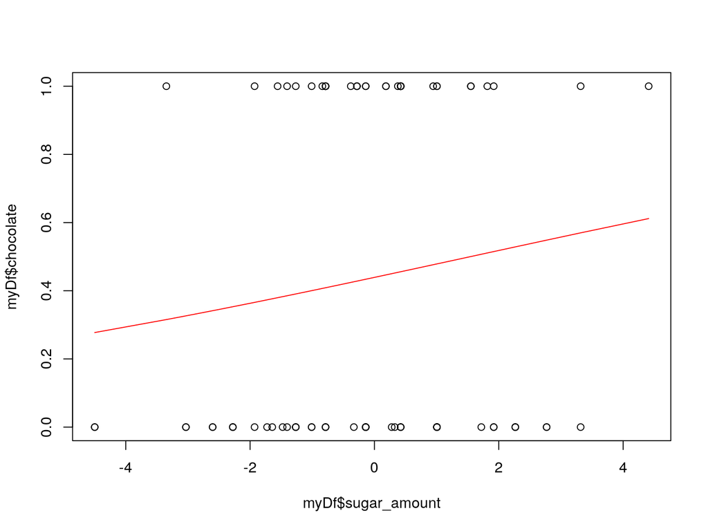

```r
mod <- glm(chocolate ~ sugar_amount, family = binomial(link = "logit"), data = myDf)
plot(myDf$sugar_amount, myDf$chocolate)
lines(myDf$sugar_amount, predict(mod, type = "response"), type = "l", col = "red")
```

`predict(mod, type = "response")` gives $\hat{y}_i$

# using `R`

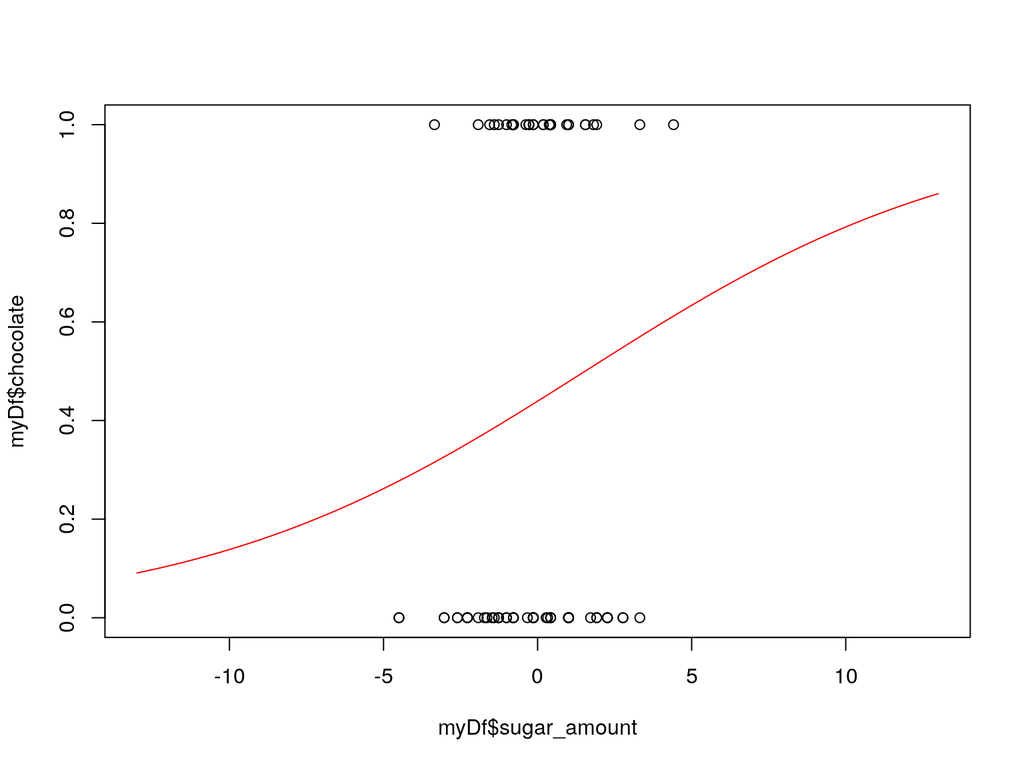

```r
left <- -13
right <- 13
plot(myDf$sugar_amount, myDf$chocolate, xlim = c(left, right))
grid <- seq(left, right, .001)
preds <- predict(mod, list(sugar_amount = grid), type = "response")
lines(grid, preds, type = "l", col = "red")
```

What do you think $\hat{\beta}_1$ is?

# using `R`

```r
summary(mod)
```

```
##
## Call:
## glm(formula = chocolate ~ sugar_amount, family = binomial(link = "logit"),
##     data = myDf)
##
## Deviance Residuals:
##    Min      1Q  Median      3Q     Max
## -1.299  -1.066  -0.914   1.254   1.519
##
## Coefficients:
##              Estimate Std. Error z value Pr(>|z|)
## (Intercept)   -0.2445     0.2208  -1.107    0.268
## sugar_amount   0.1585     0.1338   1.185    0.236
##
## (Dispersion parameter for binomial family taken to be 1)
##
##     Null deviance: 116.41  on 84  degrees of freedom
## Residual deviance: 114.96  on 83  degrees of freedom
## AIC: 118.96
##
## Number of Fisher Scoring iterations: 4
```

# Interpreting Estimates

Say you have an estimate $\hat{\beta}_3 = -1.6$. What does that even mean?

# Interpreting Estimates

Ignoring row numbers, recall that
$$\log\left( \frac{\pi}{1-\pi}\right) = \beta_0 + \beta_1 x_{1} + \beta_2 x_{2} + \beta_3 x_{3} \tag{1}$$

When only the third predictor changes…
$$\log\left( \frac{ \tilde{\pi}}{1-\tilde{\pi}} \right) = \beta_0 + \beta_1 x_{1} + \beta_2 x_{2} + \beta_3 \tilde{x}_{3} \tag{2}$$

Subtracting (1) from (2)
$$\log\left(\frac{ \tilde{\pi}}{1-\tilde{\pi}} \bigg/ \frac{\pi}{1-\pi} \right) = \beta_3 (\tilde{x}_{3} - x_{3})$$

# Interpreting Estimates

$$\log\left(\frac{ \tilde{\pi}}{1-\tilde{\pi}} \bigg/ \frac{\pi}{1-\pi} \right) = \beta_3 (\tilde{x}_{3} - x_{3})$$

For a one unit change in $x_3$, $\beta_3$ tells us the change in the log-odds, or the log odds ratio.

# Hypothesis Testing with GLMs

We now learn about how to test parameters.

All of these methods will be **asymptotic**, which means they’re only valid when you have “enough” rows/observations.

However, they can all be applied to other types of generalized linear models (GLMs) (e.g. Poisson regression, Gamma regression, multinomial regression, etc.)

# Likelihood Ratio Tests

Here’s a slide from my old STAT 3120 class:
$$-2 \log \left( \frac{ \sup_{\theta \in \Theta_0} f(x_1, \ldots, x_n ; \theta)}{ \sup_{\theta \in \Theta} f(x_1, \ldots, x_n ; \theta)}\right) \overset{\text{approx.}}{\sim} \chi^2_{\nu}$$

where $\nu$ is the number of parameters involved in the null hypothesis

The numerator is the likelihood with the maximum likelihood estimates plugged in for the **smaller** model.

The denominator is the likelihood with the maximum likelihood estimates plugged in for the **larger** model.

# Likelihood Ratio Tests

The book writes it this way:

Under $H_0: \text{RM is correct}$, the test statistic has the following sampling distribution:

$$LR = 2 \log \left(\frac{L(FM)}{L(RM) }\right) \overset{\text{approx.}}{\sim} \chi^2_{\nu}$$
where $\nu$ is the number of extra parameters in the full model. This fraction/test-statistic is called the **deviance**.

This gives us the **likelihood-ratio tests**, which assumes that **the sample size is large**.

# Likelihood Ratio Tests

$$LR = 2 \log\left( \frac{L(FM)}{L(RM) } \right)\overset{\text{approx.}}{\sim} \chi^2_{\nu}$$

We reject the null that the smaller model is true when the test statistic is “large”

$$LR > \chi^2_{\nu, \alpha}$$

or equivalently when the “p-value is low”
$$P(\chi^2_{\nu} \ge LR) < \alpha.$$

# Likelihood Ratio Tests (example 1)

The **null model** (which is also the null hypothesis **in this case** because it’s smaller):

$$\text{logit}(\pi_i) = \beta_0$$

versus the **alternative model**

$$\text{logit}(\pi_i) = \beta_0 + \beta_1 x_i$$

```r
reducedMod <- glm(chocolate ~ 1, data = myDf, family = binomial(link = "logit"))
fullMod <- glm(chocolate ~ sugar_amount, data = myDf, family = binomial(link = "logit"))
anova(reducedMod, fullMod) # remember: models must be "nested"
```

```
## Analysis of Deviance Table
##
## Model 1: chocolate ~ 1
## Model 2: chocolate ~ sugar_amount
##   Resid. Df Resid. Dev Df Deviance
## 1        84     116.41
## 2        83     114.96  1   1.4433
```

```r
1-pchisq(1.4433, 1) #don't reject and keep small model
```

```
## [1] 0.2296061
```

# Likelihood Ratio Tests (example 2)

A **goodness-of-fit** test uses the same methodology to test your chosen model:

$$\text{logit}(\pi_i) = \beta_0 + \beta_1x_{i1} + \cdots + \beta_k x_{ik},$$
which is assumed true under the null hypothesis, against a **saturated model**:

$$\text{logit}(\pi_i) = \beta_i$$

This is subtle…each row gets its very own parameter.

# Likelihood Ratio Tests (example 2)

Each row gets its own coefficent, so $\boldsymbol{\beta} \in \mathbb{R}^n$ and the design matrix is
$$\mathbf{X}\boldsymbol{\beta} =
\begin{bmatrix}
1 & 0 & \cdots & 0\\
0 & 1 & \cdots & 0\\
\vdots & \vdots & \ddots & \vdots \\
0 & 0 & \cdots & 1\\
\end{bmatrix}
\begin{bmatrix}
\beta_1 \\
\beta_2 \\
\vdots \\
\beta_n
\end{bmatrix}$$

And then we solve the same equation we mentioned before:
$$\nabla \ell(\boldsymbol{\beta}) = \sum_{i=1}^n y_i \mathbf{x}_i - \frac{\exp[ \mathbf{x}_i^\intercal \boldsymbol{\beta}]}{( 1 + \exp[ \mathbf{x}_i^\intercal \boldsymbol{\beta}] ) }\mathbf{x}_i \overset{\text{set}}{=} \mathbf{0}$$

# Likelihood Ratio Tests (example 2)

Note $\mathbf{x}_i^\intercal \boldsymbol{\beta} = \beta_i$. We must solve the following

$$\nabla \ell(\boldsymbol{\beta}) = \sum_{i=1}^n y_i \mathbf{x}_i - \frac{\exp[ \mathbf{x}_i^\intercal \boldsymbol{\beta}]}{( 1 + \exp[ \mathbf{x}_i^\intercal \boldsymbol{\beta}] ) }\mathbf{x}_i \overset{\text{set}}{=} \mathbf{0}.$$
looking at $\beta_j$:
$$\sum_{i=1}^n y_i x_{i,j} = \sum_{i=1}^n\frac{\exp[ \mathbf{x}_i^\intercal \boldsymbol{\beta}]}{( 1 + \exp[ \mathbf{x}_i^\intercal \boldsymbol{\beta}] ) }x_{i,j}$$

which can only be true if for each observation $i$:
$$y_i = \frac{\exp[ \beta_i]}{( 1 + \exp[ \beta_i ] ) } = \text{invlogit}[\beta_i]$$

or in other words each $\beta_i$ is plus or minus infinity (if $y_i$ is $1$ or $0$, respectively).

# Likelihood Ratio Tests (example 2)

A **goodness-of-fit** test uses the following test statistic:

$$2 \log\left( \frac{L(\text{saturated model})}{L( \text{model} ) } \right)$$
This has a special name: the *residual deviance*. This will be discussed in a few slides!

# Likelihood Ratio Tests (example 3)

Instead of comparing your **single** model to a small or large model, hypothesis testing can be done for two reasonable models. Say

$$\mathbf{X} \boldsymbol{\beta} = \underbrace{\mathbf{X}_1}_{p-r \text{ cols}} \boldsymbol{\beta}_1 + \underbrace{\mathbf{X}_2}_{r \text{ cols}} \boldsymbol{\beta}_2$$

and our hypotheses are

$$H_0: \boldsymbol{\beta}_2 = \mathbf{0}$$

$$H_a: \boldsymbol{\beta}_2 \neq \mathbf{0}$$

Again, under the null
$$LR = 2 \log\left( \frac{L(FM)}{L(RM) } \right)\overset{\text{approx.}}{\sim} \chi^2_{\nu}$$
and here $\nu = r$

# Likelihood Ratio Tests (example 3)

```r
myDf$sugar_amount_squared <- myDf$sugar_amount^2
reducedMod <- glm(chocolate ~ 1, data = myDf, family = binomial(link = "logit"))
fullMod <- glm(chocolate ~ sugar_amount + sugar_amount_squared, data = myDf, family = binomial(link = "logit"))
(test_results <- anova(reducedMod, fullMod)) # parentheses around assignment add printing
```

```
## Analysis of Deviance Table
##
## Model 1: chocolate ~ 1
## Model 2: chocolate ~ sugar_amount + sugar_amount_squared
##   Resid. Df Resid. Dev Df Deviance
## 1        84     116.41
## 2        82     112.10  2   4.3039
```

```r
1-pchisq(test_results$Deviance[2], test_results$Df[2])
```

```
## [1] 0.1162556
```

# Wald Tests

We also have tests on individual coefficients. The null and alternative hypotheses would be of the form

$$H_0: \beta_j = 0 \text{ versus } H_a: \beta_j \neq 0$$

These will be called **Wald Tests**, and they are based on a theorem you prove in a mathematical statistics class that shows the MLEs are asymptotically unbiased, have the lowest possible variance, and are normally distributed!

# Wald Tests

Asymptotic unbiasedness is the easier part: $E\left[\hat{\boldsymbol{\beta}} \right] \approx \boldsymbol{\beta}$. The covariance matrix has to do with the matrix of second derivatives

$$V\left[\hat{\boldsymbol{\beta}} \right] \approx [-\mathbf{G}]^{-1}$$

# Wald Tests: Understanding the Hessian

Why this is so cool:

- the Hessian matrix is output from many optimization algorithms
- this approach is justified for nearly all maximum likelihood estimation procedures, which is the most common estimation technique
- data is usually large, so not very restrictive
- no model-specific derivations (always normally distributed)

# Wald Tests: Understanding the Hessian

Why does the book write $-\mathbf{G}^{-1} = -[\nabla^2 \ell( \hat{\boldsymbol{\beta}} )] ^{-1} = (\mathbf{X}^\intercal \mathbf{V} \mathbf{X})^{-1}$?

# Wald Tests: Understanding the Hessian

Why does the book write $-\mathbf{G}^{-1} = -[\nabla^2 \ell( \hat{\boldsymbol{\beta}} )] ^{-1} = (\mathbf{X}^\intercal \mathbf{V} \mathbf{X})^{-1}$?

Recall

$$\nabla \ell(\boldsymbol{\beta}) = \sum_{i=1}^n y_i \mathbf{x}_i - \frac{\exp[ \mathbf{x}_i^\intercal \boldsymbol{\beta}]}{( 1 + \exp[ \mathbf{x}_i^\intercal \boldsymbol{\beta}] )) }\mathbf{x}_i$$

So
$$\begin{align*}
\nabla^2 \ell( \hat{\boldsymbol{\beta}} )
&=
\sum_{i=1}^n \frac{\exp[ -\mathbf{x}_i^\intercal \hat{\boldsymbol{\beta}} ] }{( 1 + \exp[- \mathbf{x}_i^\intercal \hat{\boldsymbol{\beta}} ] )^2 }\mathbf{x}_i\mathbf{x}_i^\intercal \\
&=
\mathbf{X}^\intercal
\begin{bmatrix}
\frac{\exp[ -\mathbf{x}_1^\intercal \hat{\boldsymbol{\beta}} ] }{( 1 + \exp[- \mathbf{x}_1^\intercal \hat{\boldsymbol{\beta}} ] )^2} & \cdots & 0\\
\vdots & \ddots & \vdots \\
0 & \cdots & \frac{\exp[ -\mathbf{x}_n^\intercal \hat{\boldsymbol{\beta}} ] }{( 1 + \exp[- \mathbf{x}_n^\intercal \hat{\boldsymbol{\beta}} ] )^2}
\end{bmatrix}
\mathbf{X} \\
\end{align*}$$

# Wald Tests: using `R`

Standard errors come from taking the square root of the diagonal element of the covariance matrix:
$$\hat{\beta}_j \pm z_{\alpha/2} \underbrace{\text{SE}(\hat{\beta}_j)}_{ \text{standard error}}$$

```r
confint(fullMod)
```

```
##                           2.5 %     97.5 %
## (Intercept)          -0.5159848 0.55175058
## sugar_amount         -0.1225894 0.47543798
## sugar_amount_squared -0.2543933 0.01497578
```

# Wald Tests: using `R`

`summary` gives us the Wald hypothesis tests for individual parameters

```r
summary(fullMod)
```

```
##
## Call:
## glm(formula = chocolate ~ sugar_amount + sugar_amount_squared,
##     family = binomial(link = "logit"), data = myDf)
##
## Deviance Residuals:
##    Min      1Q  Median      3Q     Max
## -1.211  -1.120  -0.753   1.182   1.931
##
## Coefficients:
##                      Estimate Std. Error z value Pr(>|z|)
## (Intercept)           0.01469    0.27094   0.054    0.957
## sugar_amount          0.16632    0.14967   1.111    0.266
## sugar_amount_squared -0.10298    0.06721  -1.532    0.125
##
## (Dispersion parameter for binomial family taken to be 1)
##
##     Null deviance: 116.41  on 84  degrees of freedom
## Residual deviance: 112.10  on 82  degrees of freedom
## AIC: 118.1
##
## Number of Fisher Scoring iterations: 4
```

# So many deviances!

Why was there a **null deviance**, and a **residual deviance**?

This is related to what we had with regular linear regression:
$$\sum_{i=1}^n(y_i - \bar{y})^2 = \sum_{i=1}^n(y_i - \hat{y}_i)^2 + \sum_{i=1}^n(\hat{y}_i - \bar{y})^2?$$

# So many deviances

**Null deviance** is kind of like $SS_T$
$$2 \log\left(\frac{L(\text{saturated model})}{L(\text{null model}) }\right)$$

**Residual deviance** is kind of like $SS_{Res}$
$$2 \log\left( \frac{L(\text{saturated model})}{L(\text{your model}) }\right)$$

# So many deviances

- **Null deviance** : $2 \log\left(\frac{L(\text{saturated model})}{L(\text{null model}) }\right)$
- **Residual deviance**: $2 \log\left( \frac{L(\text{saturated model})}{L(\text{your model}) }\right)$

So
$$2 \log\left(\frac{L(\text{saturated model})}{L(\text{null model})}\right) = 2 \log\left(\frac{L(\text{saturated model})}{L(\text{your model})}\right) + 2 \log \left( \frac{L(\text{your model})}{L(\text{null model})}\right)$$

kind of like $SS_T = SS_R + SS_{Res}$!

# Another thing: Linearly-Separable Data

Assume one predictor, no intercept
$$\pi = \text{invlogit}(x \beta)$$

What do we think $\beta$ is?

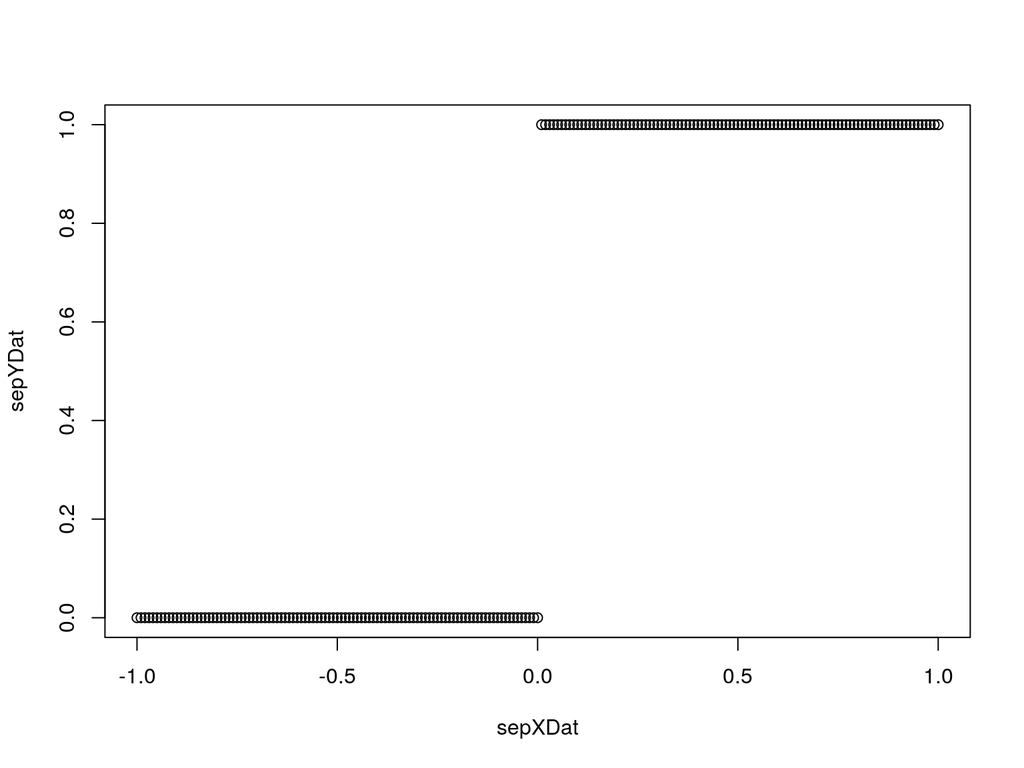

# Another thing: Linearly-Separable Data

$$\pi = \text{invlogit}(x \beta)$$

Recall

- if $x \beta = \infty$, then $\text{invlogit}(x \beta) = 1$, and
- if $x \beta = -\infty$, then $\text{invlogit}(x \beta) = 0$.

So for this linearly-separable data set:

- $x \beta = \infty$ when $y = 1$ and $x > 0$
- $x \beta = -\infty$ when $y = 0$ and $x \le 0$.

Or in other words $\beta = \infty$

# Another thing: Linearly-Separable Data

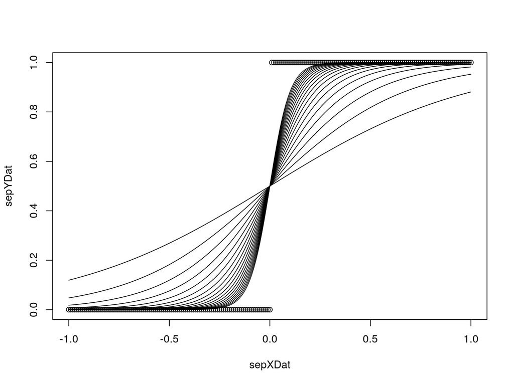

```r
sepXDat <- seq(-1,1, .01)
sepYDat <- as.numeric(sepXDat > 0)
plot(sepXDat, sepYDat, type = "p")
for(beta in 2:20)
  lines(sepXDat, inv.logit(beta*sepXDat))
```

# using `R`

In `R`:

```r
glm(sepYDat ~ sepXDat, family = binomial(link = "logit"))
```

```
##
## Call:  glm(formula = sepYDat ~ sepXDat, family = binomial(link = "logit"))
##
## Coefficients:
## (Intercept)      sepXDat
##      -14.95      2989.09
##
## Degrees of Freedom: 200 Total (i.e. Null);  199 Residual
## Null Deviance:       278.6
## Residual Deviance: 1.292e-06     AIC: 4
```

# Linearly-Separable Data

So `R` isn’t making a mistake, and the math isn’t wrong, but in practice, **this probably means you are overfitting**